# Looking for a missing surrogate...

*Unofficial title for "Bayesian surrogate construction with missing data".*

Moses Chan, for the BANDits, September 16, 2021

Additional resources for specific topics:

- **Generally useful**
  - Gramacy, R.B., 2020. *Surrogates: Gaussian process modeling, design, and optimization for the applied sciences.* Chapman and Hall/CRC.
  - Santner, T.J., Williams, B.J., Notz, W.I. and Williams, B.J., 2003. *The design and analysis of computer experiments* (Vol. 1). New York: Springer.
- **Gaussian process surrogates that *concern* about efficiency**
  - Separable covariance structure (e.g. Kronecker product)
    - Williams, B. et al., 2006. Combining experimental data and computer simulations, with an application to flyer plate experiments. *Bayesian Analysis, 1*(4), pp.765-792.
    - Bayarri, M.J., et al., 2009. Predicting vehicle crashworthiness: Validation of computer models for functional and hierarchical data. *Journal of the American Statistical Association, 104*(487), pp.929-943.
  - Principal component based Gaussian process
    - Higdon, D., et al., 2008. Computer model calibration using high-dimensional output. *Journal of the American Statistical Association, 103*(482), pp.570-583.
- **Seminal (!!) paper on Bayesian calibration**
  - Kennedy, M.C. and O'Hagan, A., 2001. Bayesian calibration of computer models. *Journal of the Royal Statistical Society: Series B (Statistical Methodology), 63*(3), pp.425-464.
- **Sequential methods related to stage-wise collection of data**
  - Gramacy, R.B. and Lee, H.K., 2009. Adaptive design and analysis of supercomputer experiments. *Technometrics, 51*(2), pp.130-145.
  - Gramacy, R.B. and Apley, D.W., 2015. Local Gaussian process approximation for large computer experiments. *Journal of Computational and Graphical Statistics, 24*(2), pp.561-578.
- **Package plug**
  - M. Plumlee, O. Surer, and S. M. Wild, *Surmise Users Manual, v. 0.1.0*, 2021. [Online]. Available: https://surmise.readthedocs.io

$\newcommand{\T}{\mathsf{T}}$

## The big picture.. why surrogates?

Ultimately, it is about effectiveness. Say we have some model $f(\theta)$, where $\theta$ is some parameter you can adjust. The model is an "attempt" to represent the physical system. And we observe and collect data from the system, call that $y$.

The relationship usually take the form of

$$ y = f(\theta) + \varepsilon. $$

The **ultimate goal** is then to find "nice" parameters such that some distance between $y$ and $f(\theta)$ is small, e.g. $\inf_{\theta} d(y, f(\theta))$.

#### One way, Bayesian calibration

Let's assume that $\varepsilon \sim N(0, W)$, then the posterior is $$ p(\theta | y) \propto \underbrace{\lvert W \rvert^{-\frac{1}{2}} \exp\left\{-\frac{1}{2}(y - f(\theta))^\T W^{-1}(y - f(\theta))\right\}}_\text{likelihood} \underbrace{p(\theta)}_\text{prior}. $$

If we stare at the likelihood long enough, and your head starts to get dizzy, gradually this $f(\theta)$ becomes less and less appealing..

$f(\theta)$.. $f(\theta)$ .. $f(\theta)$ .. $f(\theta)$ ..

...if $f(\theta)$ is computational expensive. (Reason: recall some common sampling technique for the posterior, Markov chain Monte Carlo, requires A LOT of samples. Each sample requires evaluation of the likelihood.)

#### Surrogate

What if we collect some data from $f(\theta)$ for some set of parameters $\{\theta_1, \ldots, \theta_n\}$? And we build a *surrogate* to approximate $f(\theta)$.

What we want from a surrogate are three things:

- speed: its construction and prediction should be faster than evaluating $f(\theta)$,
- prediction: around any $\theta$, we should be able to get a prediction,
- uncertainty: around any $\theta$, we should have some estimates of how much we don't know about $f(\theta)$.

#### Surrogate in Bayesian calibration

A Bayesian surrogate takes some prior with mean $\mu(\theta)$ and covariance $\Sigma(\theta)$. And we **replace** $f(\theta)$ with this surrogate.

**Assumption:** If we assume the joint distribution of $y$ and $\mathbf{f}$ being a multivariate normal, then the following posterior expression holds.

We revise the posterior as $$ p(\theta | y, \underbrace{\mathbf{f}}_\color{red}{\text{some data}}) $$ $$ \propto \lvert \underbrace{W + \hat{\Sigma}(\theta)}_\color{red}{\text{new covariance}} \rvert^{-\frac{1}{2}} \exp\left\{-\frac{1}{2}(y - \underbrace{\hat{\mu}(\theta)}_\color{red}{\text{new mean}})^\T \left(W + \hat{\Sigma}(\theta)\right)^{-1}(y - \hat{\mu}(\theta))\right\} p(\theta).$$

## Gaussian process as surrogate

We often deal with a multivariate model $$ f(\theta, x) = \begin{pmatrix} f(\theta, x_1) \\ \vdots \\ f(\theta, x_m)\end{pmatrix}. $$

For example, if $f(\theta, x)$ is an energy density functional, say with the Fayans description, then $x_1, \ldots, x_{m}$ are $m$ different nucleus configurations.

What this means is, we collect data for parameters $(\theta_1, \ldots, \theta_n)$ as

$$ \mathbf{f} = \begin{pmatrix} f(\theta_1, x)^\T \\ \vdots \\ f(\theta_n, x)^\T \end{pmatrix} = \begin{pmatrix} f(\theta_1, x_1) & \ldots & f(\theta_1, x_m) \\ \vdots & \ddots & \vdots \\ f(\theta_n, x_1) & \ldots & f(\theta_n, x_m) \end{pmatrix}. $$

**Some considerations about building the surrogate** - Build a separate surrogate for each $x_i$? But this loses the correlation structure along $x$. - Model $(\theta, x)$ together (which accounts for all correlations). This means to stack everything as a single column. Why not? Too expensive, since constructing GP typically takes $\mathcal{O}(N^3)$, $N = nm$ in this case, and usually GP construction is limited to $N < 10^4$.

#### Dimension reduction idea (PCGP = Principal Component GP)

Take Higdon et al. (2008), we decompose $\mathbf{f}$ with a singular value decomposition as

$$ \mathbf{f} = USV^\T, $$

where $U^\T U = I_n, V^\T V = I_m$, and $S \in \mathcal{R}^{n\times m}$ is a diagonal matrix that contains the singular values.

But we can truncate $U$ and $V$ to result in $$ \mathbf{f} \approx \tilde{U}_{n\times K}\tilde{S}_{K\times K}\tilde{V}_{K \times m}^\T.$$

In practice, we only need either $U$ or $V$.

#### Illustration of SVD

```python
import numpy as np
from scipy.linalg import svd
np.set_printoptions(precision=3)

n = 20
m = 5
M1 = np.random.normal(size=(n, m))
f = np.zeros((n, 2*m))
f[:, :m] = M1
f[:, m:] = 2*M1  # creating a matrix with correlated columns
print('f\'s shape = \n', f.shape,'\n')


U, S, _ = svd(f.T, full_matrices=False)
print('diagonal of S = \n', S)

# from scipy.linalg import eigh
# lam = eigh(f.T @ f, eigvals_only=True)
# print(np.flip(lam) - S**2)
```

```
f's shape =
 (20, 10)

diagonal of S =
 [1.145e+01 1.082e+01 1.013e+01 8.414e+00 7.199e+00 1.833e-15 8.415e-16
 6.705e-16 3.488e-16 1.772e-16]
```

Check if $U^\T U$ is identity..

```python
np.isclose(U.T @ U, np.eye(2*m)).all()
```

```
True
```

```python
eps = 10e-8
K = len(S > eps) # Take only the first K components

pct = U[:, :K]
pc = f @ pct  ## "relevant" principal component

fhat = pc @ pct.T

print('Error between fhat and f:', ((fhat - f)**2).sum())
```

```
Error between fhat and f: 3.817112862570945e-28
```

#### Using Gaussian process with SVD

A quick reminder that $U$ or $V$ is orthonormal, which means $\mathbf{f}$ has been transformed to some lower dimensional representation with uncorrelated columns.

(I have been using $\Phi_{m\times K}$ as $\tilde{V}^\T$, so... with some inconsistent notation, we move forward.)

If we assume this transformation relationship:

$$ f(\theta) \approx \Phi g(\theta), $$

which also means

$$ \mathsf{cov}(f(\theta)) \approx \Phi \mathsf{cov}(g(\theta)) \Phi^\T. $$

Now the lower dimensional object is $\mathbf{g}_{n\times K} = \mathbf{f} \Phi$. Then each column of $\mathbf{g}$, $\mathbf{g}_{\cdot, k},$ can be modeled with an independent Gaussian process, namely

$$ g_k(\cdot) \sim \mathsf{GP}(0, \rho_k(\cdot,\cdot)) $$

#### Prediction using this method

Each component has a predictive mean and variance

\begin{equation} \label{eqn:gppred} \hat{\mu}_k(\theta) = \mathbf{r}_k^\T(\theta) \mathbf{R}_k^{-1} \mathbf{g}_{\cdot,k}, \quad \hat{\sigma}^2_k(\theta) = \rho_k(\theta, \theta) - \mathbf{r}_k^\T(\theta)\mathbf{R}_k^{-1}\mathbf{r}_k(\theta) , \end{equation}

where \begin{equation} \mathbf{r}_k(\theta) = \begin{pmatrix} \rho_k(\theta, \theta_1) \\ \vdots \\ \rho_k(\theta, \theta_n) \end{pmatrix}, \quad \mathbf{R}_k = \begin{pmatrix} \rho_k(\theta_1, \theta_1) & \ldots & \rho_k(\theta_1, \theta_n) \\ \vdots & \ddots & \vdots \\ \rho_k(\theta_n, \theta_1) & \ldots & \rho_k(\theta_n, \theta_n) \\ \end{pmatrix}. \nonumber \end{equation}

**How about the surrogate for $f(\theta)$???**

We transform these component predictions back using $\Phi$, using the mean and covariance being

\begin{equation} \mu(\theta) = \Phi \begin{pmatrix} \hat{\mu}_1(\theta) \\ \vdots \\ \hat{\mu}_K(\theta) \end{pmatrix}, \quad \Sigma(\theta) = \Phi \left[\mathrm{diag}(\hat{\sigma}^2_1(\theta), \ldots, \hat{\sigma}^2_K(\theta))\right] \Phi^\T. \end{equation}

## Finally, the real problem...

All we did so far is living in a pretty nice world, which is far from reality...

$\mathbf{f}$ looks more like this:

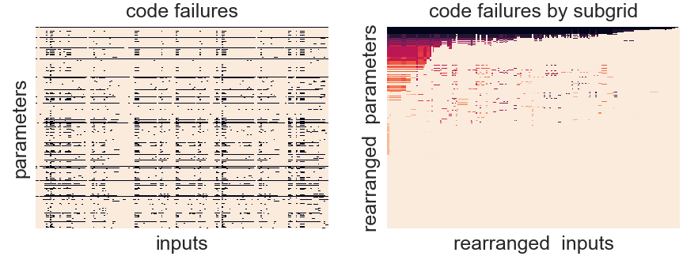

where the dark spots are simply $\mathsf{NA}$'s in the data.

#### Why does PCGP not work here?

It all comes down to this expression:

$$ \mathbf{g}_{n\times K} = \mathbf{f} \Phi. $$

- It's not clear how $\Phi$ is even computed, since SVD is used for complete matrices.
- Even if we somehow have $\Phi$, any missing values in rows of $\mathbf{f}$ propagates to rows of $\mathbf{g}$.

**Idea: What if we impute the missing values first?** (Ignoring how $\Phi$ can be computed.. )

Going back to our covariance relationship between the original function and the lower dimensional function

\begin{align} \mathsf{cov}(f(\theta)) &\approx \Phi \mathsf{cov}(g(\theta)) \Phi^\T \\ &= \Phi \left[\mathrm{diag}(\lambda_1, \ldots, \lambda_K) \right] \Phi^\T, \end{align}

where $\lambda_k = S_{kk}^2$ is the $k$th eigenvalue of ${\mathbf{f} \mathbf{f}}^\T$.

Call this entire expression $B_{m\times m} := \Phi \Lambda \Phi^\T$.

Take a specific row of $\mathbf{f}$, e.g.

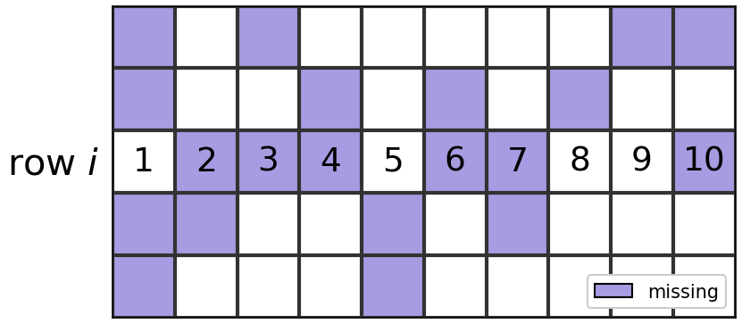

Define $J(i)$ to be the set of indices where data are available, e.g. $\{1,5,8,9\}$.

(Ignoring some invertibility issues here...) **impute the lower dimensional $\mathbf{g}$** using mean

$$ \tilde{\mathbf{g}}_{i,\cdot}= \left(\mathbf{f}_{i,J(i)} B_{J(i),J(i)}^{-1} B_{J(i), \cdot} \Phi\right)^\T, $$

and its predictive variance (due to imputation)

$$ \mathsf{cov}\left(\tilde{\mathbf{g}}_{i,\cdot} - \mathbf{g}_{i,\cdot}\right) := C(J(i)) = \Phi^\T \left(B - B_{\cdot, J(i)} B_{J(i),J(i)}^{-1} B_{\cdot, J(i)}^\T \right) \Phi. $$

**Recovery property** If $J(i) = \{1, \ldots, m\}$, then $\tilde{\mathbf{g}}_{i,\cdot} = \mathbf{g}_{i,\cdot}$ with no uncertainty, i.e. $C(J(i)) = \mathbf{0}$.

We have complete data again!

So we predict with a $\mathsf{GP}$ (incorrectly),

\begin{equation} \tilde{\mu}_k(\theta) = \mathbf{r}_k^\T(\theta) \mathbf{R}_k^{-1} \tilde{\mathbf{g}}_{\cdot,k}, \quad \hat{\sigma}^2_k(\theta) = \rho_k(\theta, \theta) - \mathbf{r}_k^\T(\theta)\mathbf{R}_k^{-1}\mathbf{r}_k(\theta) , \end{equation}

**Covariance adjustment**

We want $\mathbf{R}_k$ to incorporate the imputation variances as well.

Now, assign the imputation variances for each row to be

$$ w_{ik} := \frac{C(J(i))_{k,k}}{\lambda_k}$$

\begin{align} \mathbf{R}_k + \beta_k \mathrm{diag}(\mathbf{v}_k), \label{eqn:adjusted_cov} \\ \quad \text{where } \mathbf{v}_k &= (v_{1k}, \ldots, v_{nk})^\T, \quad \text{and} \nonumber \\ v_{ik} &:= \frac{w_{ik}}{(1 - w_{ik})^\alpha}, \\ \alpha, \beta &\geq 0. \end{align}

**What's the deal with $\alpha$??**

**Case** $\alpha=0:$ $v_{ik} = w_{ik}$. Imagine a row with no data at all, $w_{ik}$ would become 1. But does this make sense? After all, we have learned nothing about this row, why should the variance be 1?

If $\alpha > 0$, then we get something like the following:

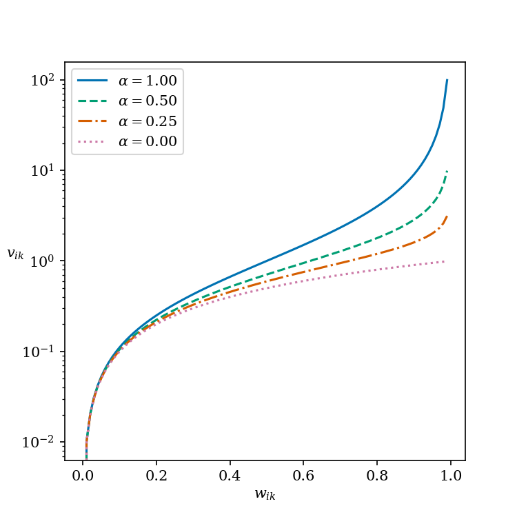

The variance for that row blows up if no data is available.

**What about $\beta_k$'s??**

How much of this imputation variance is added to the original covariance matrix?

It is possible to optimize $\beta_k$ through inclusion in the posterior.

Component mean

$$ \tilde{\mu}_k(\theta) = \mathbf{r}_k^\T(\theta) \left(\mathbf{R}_k + \beta_k \mathrm{diag}(\mathbf{v}_k)\right)^{-1} \tilde{\mathbf{g}}_{\cdot,k}, $$

and variance

$$ \tilde{\sigma}^2_k(\theta) = \rho_k(\theta, \theta) - \mathbf{r}_k^\T(\theta)\left(\mathbf{R}_k + \beta_k \mathrm{diag}(\mathbf{v}_k)\right)^{-1}\mathbf{r}_k(\theta) .$$

### Final surrogate predictions

\begin{equation} \label{eqn:rev_surrogate} \mu(\theta) = \Phi \begin{pmatrix} \tilde{\mu}_1(\theta) \\ \vdots \\ \tilde{\mu}_K(\theta) \end{pmatrix}, \quad \Sigma(\theta) = \Phi \left[\mathrm{diag}(\tilde{\sigma}^2_1(\theta), \ldots, \tilde{\sigma}^2_K(\theta))\right] \Phi^\T. \end{equation}

## Some computational results (i.e. not equations)

Construction time

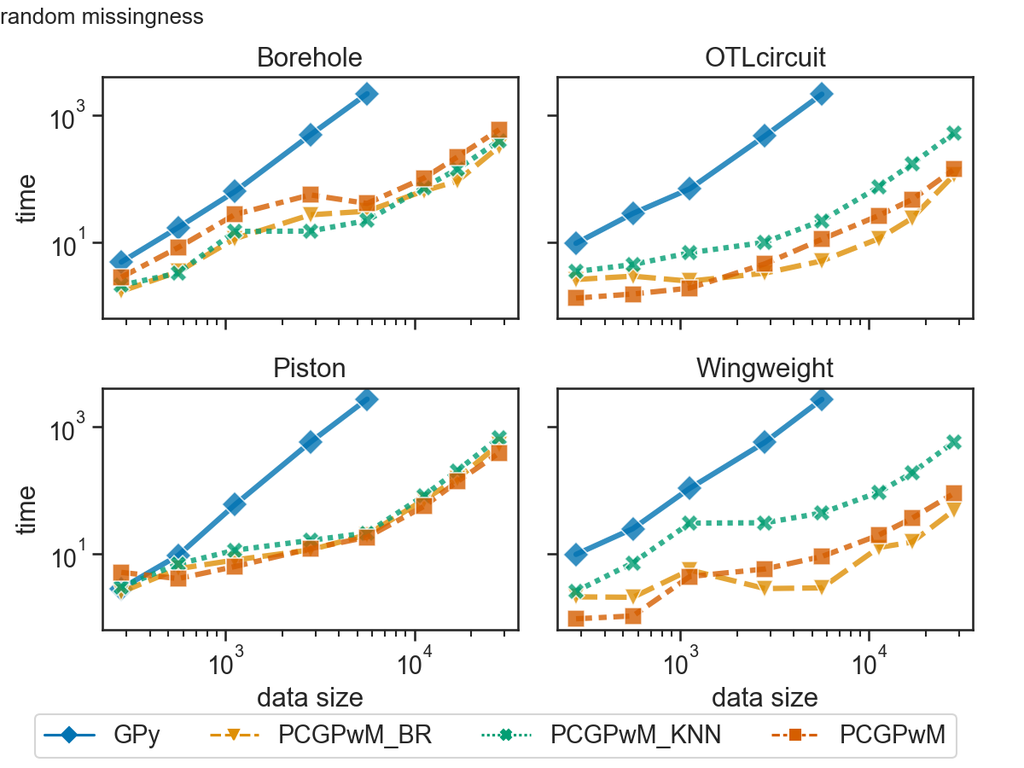

90% Coverage

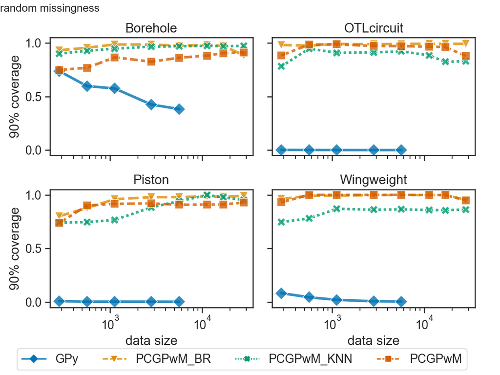